# presentation on git, a DVCS

#### merge master into my-exp-fixes

[figure not shown]

#### merge done

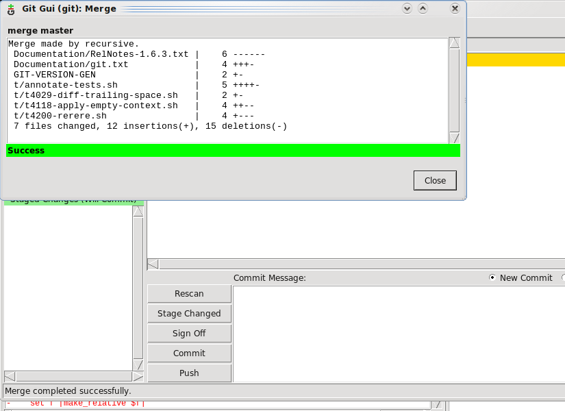

#### view in gitk

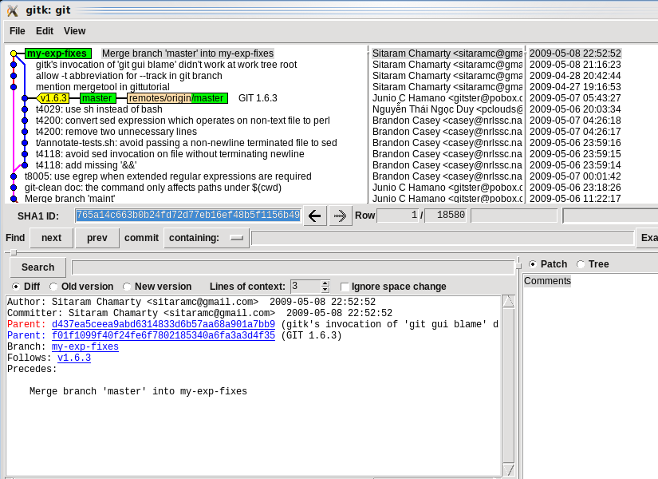

#### starting point for a rebase

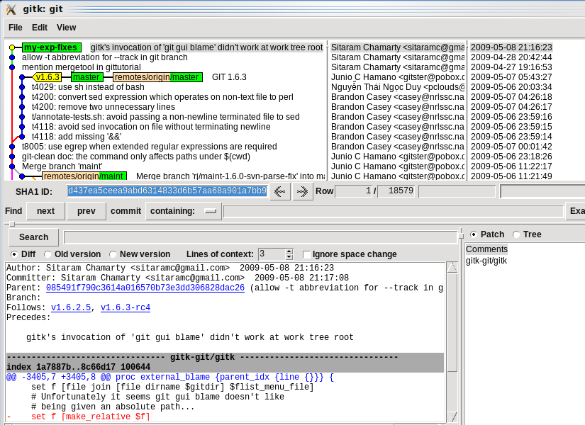

#### rebase my-exp-fixes onto master (CLI)

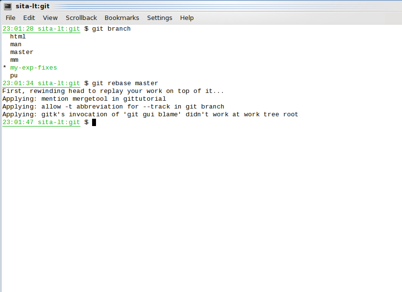

#### view in gitk

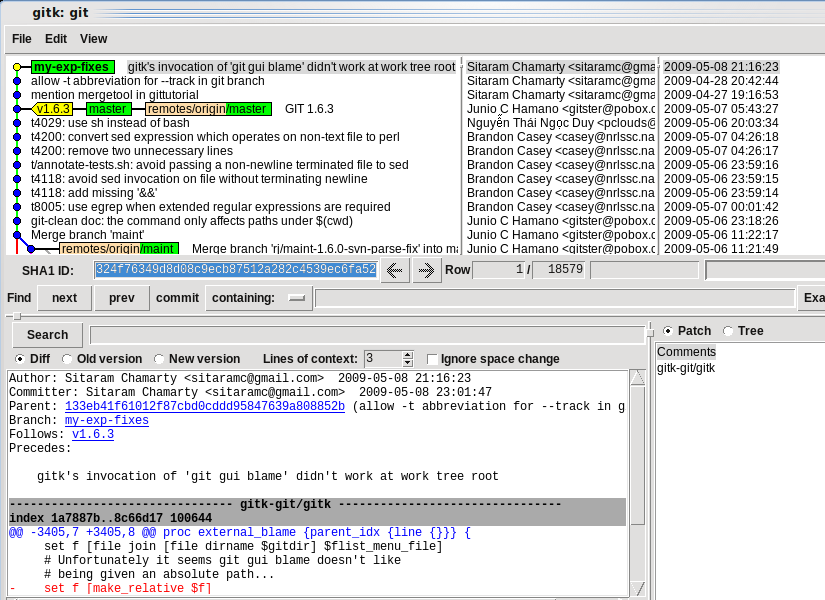

# 8 closing up

# 8.1 odds and ends

- only one “.git” dir at the top
- patches and repo updates can be ftp-d or mailed
- multi-protocol transport
  - http, ssh, git
- all copies of a repo have the same history
  - universal public identifier (a SHA-1 hash)
  - entire 2 year history of linux kernel is half the current full size

# 8.2 summary: what is git optimised for

- distributed development
- large file sets
- complex merges
- speculative, trial branches
- EXTREME SPEED – very fast and very robust